# Curso Coda

Manoel

11 de novembro de 2018

## Início

Essa é o tutorial para o curso de R para análise de políticas públicas. A oficina prática ensinará como utilizar o software R para fazer análises estatísticas e manuseio de microdados de políticas públicas. Iremos aprender a importar dados simples e as principais bases de dados de microdados do Brasil, e fazer análises básicas delas. Ao final da oficina, o participante saberá as principais funções para usar o R em análises de políticas públicas. Ao longo do dia iremos:

```
1. Conhecer o R;
2. Importar planilhas em formatos .xlsx (Excel) e .csv no R;
3. Criar tabelas e visualizações com os verbos do dplyr;
4. Exportar bancos de dados;
5. Juntar diferentes bancos de dados com o left_join;
6. Aprender a fazer gráficos com ggplot2
7. Trabalhar problemas do mundo real na parte 2 e conhecer algumas bases de dados mais relevantes (microdados).
```

## Primeiros passos

O curso tem bastante similaridade com o curso de R que dei no congresso da ABraji. Antes de começarmos, precisamos entender algumas coisas sobre o R:

### O que é uma linguagem?

Quando falamos que *R é uma linguagem* queremos dizer que através do R utilizamos uma forma específica para nos comunicarmos com o computador. Através dessa linguagem, podemos fazer perguntas e comandos para o computador e ele nos dirá a resposta.

**Dica**

Sempre verifique se você digitou *corretamente* as funções no R. Muitos dos problemas enfrentados pelos usuários são causados por uma vírgula fora do lugar.

### Por quê usar o R?

```
1. Método Seguro;
2. Rapidez;
3. Possui uma grande comunidade.
```

### R e Rstudio

O R é uma linguagem de programação voltada para análise de dados e um software gratuito para compilação de dados. Já o Rstudio é uma IDE (*Integrated Development Enviroment*) que nos ajuda a visualizar o código e o que está armazenado para uso na memória RAM, sendo assim mais *“amigável”* que a interface padrão do R. Para usar o RStudio é necessário ter o R no seu computador.

Caso precisem instalar o R ou o RStudio, [siga o tutorial disponível aqui](https://github.com/voigtjessica/curso_R_ABRAJI_28062018/blob/master/como_instalar_r.rmd) .

## 1. Conhecendo o R

O **script** é a parte superior esquerda da tela, ele serve para que você escreva e armazene o código para verificação posterior. Essa é uma das maiores vantagens de se usar o R, pois você pode verificar o que você fez e corrigir eventuais erros que tenha cometido. Iremos escrever um comando no script, clicar em executar (run) ou apertar ctrl + enter, e o Rstudio vai executá-lo.

Na parte superior direita temos três abas: *Enviroment e History*, por enquanto vamos apenas trabalhar com a aba Enviroment. Nela podemos conferir os objetos que criamos ou importamos.

Na parte inferior direita estão as abas *Files, Plots, Packages, Help e Viewer*. Não vamos nos preocupar com essa parte nesse momento.

Na parte inferior esquerda está o console, é onde você verá a impressão dos códigos rodados e eventuais mensagens e erros.

### Como iremos trabalhar?

As partes cinzas desse documento são chamadas chunks. Copie e cole os chunks no seu script para executar as operações. Comente no próprio script as suas impressões e como você traduziria esse código para uma linguagem que você entenda.

### Comentários

Ao fazer um script, é recomendável que você comente o seu código para demarcar etapas ou até mesmo lembrar para o que determinado comando serve. Para isso. utilize a #

```r
######## Curso de R análise de políticas públicas
# Assim é que se faz um comentário no script
```

### O que são objetos?

Tudo no R é um objeto, por exemplo o número π:

```r
pi
```

```
## [1] 3.141593
```

E as funções também são objetos. Vejamos o exemplo da função sum (SOMA)

```r
sum(2,3,4)
```

```
## [1] 9
```

E podemos criar nós mesmos os nossos objetos utilizando o operador de atribuição <- Esses objetos ficarão disponíveis no *Global Environment* e, assim, poderemos utilizá-los depois.

```r
resultado_da_soma <- sum(2,3,4)
resultado_da_soma
```

```
## [1] 9
```

Ou

```r
x <- 2
y <- 3
z <- 4
x+y+z
```

```
## [1] 9
```

### Tipos ou classes de objetos no R

**Numeric** São números reais

```r
4
```

```
## [1] 4
```

**Character**: Vetores tipo texto, escritos entre aspas duplas ou simples:

```r
"4"
```

```
## [1] "4"
```

```r
'4'
```

```
## [1] "4"
```

### Pacotes

O R possui algumas funções nativa como, por exemplo, a função *sum()* . No entanto, é possível importar novas funções e até mesmo bancos de dados por meio de pacotes.

Para a aula de hoje, vamos importar o pacote *data.table* para usarmos o comando *fread*, que nos permite importar arquivos .csv de forma mais eficiente. Execute os comandos a seguir:

```r
# Instalar o pacote na nossa máquina com a função install.packages()
# Aqui mostramos como comentário porque o pacote já está instalado:
# install.packages("data.table") #nome do pacote entre aspas
# Carregar a biblioteca com a função library()
library(data.table)
```

Se não der nenhuma mensagem de erro, é porque deu certo.

Agora nós temos acesso ao comando *fread* e podemos importar o nosso banco de dados. Você só precisa carregar a biblioteca uma vez depois de abrir o R e iniciar a sessão.

É uma prática comum indicar as bibliotecas que serão usadas no início do script, no entanto, a longo do curso de hoje faremos um pouco diferente: sempre que utilizarmos um comando que pertence a uma biblioteca, vamos mostrar a biblioteca como um comentário. Vejam o exemplo a seguir (por favor, não rodem):

```r
#library(data.table) ou
#data.table:fread
idh <- fread(file = "idh.csv")
```

## 2. Importar planilhas em formatos .xlsx (Excel) e .csv no R

Agora que já sabemos como importar bibliotecas e como acessar objetos, vamos aprender a importar banco de dados. Vamos trabalhar com o banco de jogadores da fifa de 2018.

```
1. Vá em https://goo.gl/XUWoyR e baixe o arquivo "fifa2018.xls" e o arquivo "idh.csv";
2. Salve os arquivos em uma pasta conhecida.
```

### Importando arquivos em .csv

CSV significa *Comma Separated Values*, e é um tipo de arquivo para armazenar banco de dados. Nós podemos importar arquivos .csv com o comando *fread()* , da biblioteca *data.table*.

Primeiro, temos que avisar o computador onde está o arquivo que queremos importar. Para isso, cole o caminho onde está o seu arquivo entre aspas dentro da função *setwd()* . Lembre-se de que no R as barras apontam para a direita “/” como no exemplo abaixo:

```r
# Comandos nativos do R (não precisam de biblioteca)
# Definindo o caminho
setwd("C:/Users/mgaldino/2018/Pessoal/curso_coda")
#Verificando o caminho:
getwd()
```

Agora vamos mostrar como importar o arquivo “idh.csv” e atribui-lo a um objeto chamado idh:

```r
# library(data.table)
# Importar arquivo .csv
idh <- fread(file = "idh.csv")
# Comando nativo
# Abre em uma outra janela o dataframe
View(idh)
```

Por enquanto vamos deixar esse banco de lado. Voltaremos nele mais pra frente.

### Importando arquivos em excel .xls

Agora vamos importar o arquivo. Para isso, vamos usar a função *read_excel()* do pacote *readxl* por meio dos comandos disponíveis na interface do R Studio. A vantagem de importar arquivos excel dessa forma é poder verificar como cada coluna será importada e alterá-las, se necessário.

```
Vá em *File >> Import Datasets >> from Excel >> Browse*
```

Algumas colunas estão corretamente classificadas como character(texto), mas outras terão de ser alteradas antes de importadas. As colunas “height”, “caps” e “goals” estão como character, mas deveriam estar como numeric. Clique na seta ao lado do nome de cada coluna e mude a sua classe.

Você poderá perceber que o código descrito no canto inferior direito irá se modificar conforme você vai alterando a classe das colunas. Após alterar a classe dessas três colunas, copie o código e clique em *import* . Por fim, cole o código no seu script para registro. Ele estará parecido com o código abaixo:

```r
# Carregando a biblioteca readxl
library(readxl)
# Importando o dataframe e atribuindo ao objeto fifa2018
fifa2018 <- read_excel("C:/Users/mgaldino/2018/Pessoal/curso_coda/fifa2018.xlsx",
    col_types = c("text", "text", "text",
        "text", "text", "text", "text", "text",
        "numeric", "numeric", "numeric",
        "text"))
# Abre em uma outra janela o dataframe
View(fifa2018)
```

Vamos agora dar uma olhada nesse banco?

## 3. Criar tabelas e visualizações com os verbos do dplyr

Se o R é uma linguagem, o dplyr é uma lista de verbos que nos permite “conversar” com a máquina de maneira mais eficaz. Durante o curso de hoje, vamos aprender a analisar dados utilizando os verbos do dplyr.

Primeiro vamos instalar e carregar a biblioteca:

```r
# install.packages("dplyr")
# Esse pacote já foi instalado no computador.
library(dplyr)
```

O dplyr possui um verbo próprio para verificar a base de dados, o *glimpse()* . Você pode utilizar em conjunto com os comandos acima. Com o glimpse, podemos conferir o nome, classe e as primeiras entradas de um data.frame.

```r
#library(dplyr)
# "olhar" o dataframe
glimpse(fifa2018)
```

### Criando novas variáveis

Para criar novas colunas ou sobrescrever uma coluna em um dataframe, utilizamos o verbo *mutate()*.

Se quisessemos dizer que todas essas linhas se referem a jogos de futebol, poderiamos criar uma nova coluna que indicasse o esporte:

```r
# dplyr:mutate
fifa2018_1 <- fifa2018 %>%  # Pegue o fifa2018 e atribua ao objeto fifa2018_1, então
  mutate(esporte = "futebol")  # Crie uma váriável chamada esporte com o valor "futebol"
glimpse(fifa2018_1)
```

Pronto, criamos uma coluna “esporte” com o valor único “futebol”.

Agora, digamos que vocês estão elaborando as estatísticas dos jogadores antes da copa. Com essas informações da Fifa, seria interessante saber qual é a média de gols por jogador com a camisa da sua seleção. Para isso vamos criar uma nova coluna que divide o número de gols (goals) pelo número de jogos pela seleção (caps).

```r
fifa2018_1 <- fifa2018 %>%
  mutate(media_gols = goals/caps)
glimpse(fifa2018_1)
```

Essa média ficou com muitas casas decimais, não acham? Podemos controlar o número de casas decimais (no R representados pelo .) utilizando o *round()*, que arredonda números:

```r
#nativo:round
# Testando:
round(4.567899765 , 1) #uma casa decimal
round(4.567899765 , 3) #três casas decimais
# Agora em um dataframe:
fifa2018_1 <- fifa2018 %>%
  mutate(media_gols = round(goals/caps , 1))
glimpse(fifa2018_1)
```

Melhor, não?

O mutate pode ser usado tanto para criar uma nova variável completamente nova quanto para sobreescrever variáveis que já existem.

Vejamos um exemplo: a altura dos jogadores está em cm, que tal se ela estivesse em metros? Basta sobrescrever:

```r
fifa2018_1 <- fifa2018 %>%
  mutate(height = (height/100))
glimpse(fifa2018_1)
```

O mutate também pode mudar apenas a classe da variável. Lembra de como nós mudamos as variáveis “height”, “caps” e “goals” de character para numeric ? Poderíamos ter feito isso também com o mutate. Vejamos primeiro como podemos transformar a classe de vetores:

```r
#nativo: as.numeric
#nativo: as.character
# Exemplo
vetor_texto <- c("22", "23", "24")        #criando o vetor
class(vetor_texto)                        #verificando a classe do vetor
# Transformando em numeric:
vetor_texto <- as.numeric(vetor_texto)
class(vetor_texto)
# Transformando outra vez em character:
vetor_texto <- as.character(vetor_texto)
class(vetor_texto)
```

Viram? Com as funções nativas do R *as.numeric()* e *as.character()* podemos transformar um objeto de uma classe em outra.

Agora vamos aplicar o que aprendemos no dafatrame da fifa. Vamos:

1. Transformar a coluna “goals” em character e atribuir ao objeto fifa2018_1,
2. Depois sobrescrever o objeto fifa2018_1 e transformar “goals” em numeric outra vez:

```r
fifa2018_1 <- fifa2018 %>%
  mutate(goals = as.character(goals))
glimpse(fifa2018_1)
# Viram? e agora outra vez:
fifa2018_1 <- fifa2018_1 %>%
  mutate(goals = as.numeric(goals))
glimpse(fifa2018_1)
```

### Modificando datas

Vocês devem ter reparado que não mudamos a coluna day_of_birth no momento da importação. Datas costumam ser complicadas e requerem um tratamento especial.

Assim como *as.character()* e *as.numeric()*, nós temos o comando *as.Date()* - sim, com D maiúsculo - que transforma um vetor em vetor de data. Então, para classificar um vetor ou coluna de texto para data, temos que aplicar o *as.Date()* e mostrar ao R como ele deve ler a data, em outras palavras indicar o dia, o mês e o ano e qual é o separador usado.

Vamos ver o *as.Date()* utilizado junto com o *mutate()* no exemplo abaixo:

```r
#nativo:as.Date
#Vamos verificar como estão a data no nosso dataframe:
glimpse(fifa2018)
# "10.02.1986" -> "%d.%m.%Y"
# Agora vamos transformar em data com o mutate:
fifa2018_1 <- fifa2018 %>%
  mutate(day_of_birth = as.Date(day_of_birth, format="%d.%m.%Y"))
glimpse(fifa2018_1)
```

Agora vamos aplicar todas as transformações que já fizemos juntas? Para isso, basta “colar” um comando ao outro com o pipe:

```r
fifa2018_1 <- fifa2018 %>%
  mutate(esporte = "futebol") %>%                # Esporte = Futebol
  mutate(media_gols = round(goals/caps, 1)) %>%  # Coluna de média de gols por jogos com 1 casa decimal
  mutate(height = (height/100)) %>%              # Altura dos jogadores em metros
  mutate(day_of_birth = as.Date(day_of_birth, format="%d.%m.%Y"))  # Convertendo dia do nascimento em data.
glimpse(fifa2018_1)
```

Agora, ficar repetindo o comando (mutate) é muito chato. Lembrem-se: **programadores são preguiçosos**. No dplyr, você pode dizer o comando uma vez e colocar tudo o que diz respeito àquele comando dentro do parenteses. Então o nosso código ficaria assim:

```r
fifa2018_1 <- fifa2018 %>%
  mutate(esporte = "futebol",
         media_gols = round(goals/caps , 1),
         height = (height/100),
         day_of_birth = as.Date(day_of_birth, format="%d.%m.%Y"))
glimpse(fifa2018_1)
```

```
## Observations: 736
## Variables: 14
## $ number            <chr> "1", "2", "3", "4", "5", "6", "7", "8", "9",...
## $ fifa_display_name <chr> "Nahuel GUZMAN", "Gabriel MERCADO", "Nicolas...
## $ last_name         <chr> "GUZMÁN", "MERCADO", "TAGLIAFICO", "ANSALDI"...
## $ first_name        <chr> "Nahuel Ignacio", "Gabriel Ivan", "Nicolás A...
## $ shirt_name        <chr> "GUZMÁN", "MERCADO", "TAGLIAFICO", "ANSALDI"...
## $ day_of_birth      <date> 1986-02-10, 1987-03-18, 1992-08-31, 1986-09...
## $ position          <chr> "GK", "DF", "DF", "DF", "MF", "DF", "MF", "D...
## $ club              <chr> "Tigres (MEX)", "Sevilla FC (ESP)", "Ajax (N...
## $ height            <dbl> 1.92, 1.81, 1.69, 1.81, 1.75, 1.99, 1.75, 1....
## $ caps              <dbl> 6, 21, 6, 5, 58, 9, 63, 11, 74, 126, 95, 0, ...
## $ goals             <dbl> 0, 3, 0, 1, 1, 1, 6, 0, 31, 64, 19, 0, 0, 3,...
## $ team              <chr> "Argentina", "Argentina", "Argentina", "Arge...
## $ esporte           <chr> "futebol", "futebol", "futebol", "futebol", ...
## $ media_gols        <dbl> 0.0, 0.1, 0.0, 0.2, 0.0, 0.1, 0.1, 0.0, 0.4,...
```

Mais limpo, não acham? E como não fechamos o parenteses do *mutate()*, não precisams colocar o pipe para continuar com o código.

### Renomeando variáveis:

Para renomear variáveis, usamos o *rename()* do pacote dplyr, indicando primeiro o nome novo e depois o nome antigo.

Importante: o R tem dificuldade em ler nomes com espaços e acentuação. Por isso, é uma boa prática sempre deixar todas as letras das variáveis como minúsculas para evitar erros na hora de digitar o código.

```r
#dplyr:rename
fifa2018_1 <- fifa2018 %>%
  rename(jogos_com_a_selecao = caps) #sem acento e sem espaço
```

### Filtrando e re-arranjando

Digamos que nos interessemos em saber qual jogador tem a maior média de gols com a camisa da seleção? Ou que não queremos dados de jogadores sem gols. Como fazer?

O verbo *filter()* permite com que selecionemos apenas as entradas (linhas) que nos interessam. Para escrever corretamente, precisamos saber **exatamente** como está escrito aquilo que queremos filtrar. Para isso costumamos usar o *glimpse()* ou o *unique()*.

Vamos trabalhar no nosso banco fifa2018_1 . Quais são os times que estão em campo? Para saber os valores únicos dentro de cada coluna, usamos o *unique(nomedobanco$nomedacoluna)* :

```r
#nativo:unique
unique(fifa2018_1$team)
```

Agora que vimos como está escrito, vamos filtrar os resultados para:

```r
#dplyr:filter
# Brasil:
brasil <- fifa2018_1 %>%
  filter(team == "Brazil")
glimpse(brasil)
# América do Sul:
america_do_sul <- fifa2018_1 %>%
  filter(team == "Brazil" | team == "Argentina" | team == "Colombia" | team == "Peru" | team == "Uruguay")
glimpse(america_do_sul)
# Jogadores do Brasil com 2 ou mais gols:
brasil2 <- fifa2018_1 %>%
  filter(team == "Brazil" & goals >=2)
glimpse(brasil2)
# Jogadores do Irã com mais de 20 anos (nascidos antes de 1998):
ira <- fifa2018_1 %>%
  filter(team == "IR Iran" & day_of_birth < "1998-01-01")
glimpse(ira)
# Apenas os jogadores que fizeram gols:
jog_gols <- fifa2018_1 %>%
  filter(goals != 0)
glimpse(jog_gols)
```

Outro modo de selecionar é com o *slice()*, que fatia a tabela, com o *select()*, que seleciona algumas colunas e com o *arrange()* , que ordena as linhas.

Vamos então selecionar apenas o nome(“fifa_display_name”) e a seleção(“team”) e os gols (“goals”) dos 5 jogadores com a maior número de gols(“goals”):

```r
top5 <- fifa2018_1 %>%
  arrange(desc(goals)) %>%                # ordenando os gols em ordem decrescente
  slice(1:5) %>%                          # selecionando as 5 primeiras linhas
  select(fifa_display_name, team, goals ) #selecionando as colunas
top5
```

### Tabelas dinâmicas

No excel, é normal criarmos tabelas dinâmicas para analisarmos uma planilha. Elas agrupam e somam ou contam as entradas. Vamos aprender como fazer tabelas dinâmicas no R com o *group_by()* e o *summarise()* .

Primeiro, vamos qual é a **soma** de gols (“goals”) por time (“team”) do nosso banco:

```r
gols_time <- fifa2018_1 %>%
  group_by(team) %>%                      # agrupando por "team"
  summarise(gols_feitos = sum(goals))     # somando os valores da coluna "goals"
gols_time
```

O *summmarise()* cria uma nova coluna. O nome é atribuído no momento da criação (“gols_feitos”) e o valor da coluna é a operação que desejamos (*sum(goals)*) .

### Exercício 1:

```
1. Atribua a um objeto "top_5_times" o banco "fifa2018_1", então
2. Agrupe por time com o group_by(), então
3. Some o número total de "goals" com o summarise(), então
4. Ordene os gols em ordem decrescente com o arrange(), então
5. Selecione as 5 primeiras linhas com o slice() .
```

Vamos fazer um segundo exemplo com o *group_by()* e *summarise()* . Agora vamos ver a altura (height) média dos jogadores por seleçao (team):

```r
altura_time <- fifa2018_1 %>%
  group_by(team) %>%                       # agrupando
  summarise(altura_media = mean(height))   # calculando a média das alturas
altura_time
```

### Exercício 2:

```
1 Atribua a um novo objeto o objeto "altura_time"que acabamos de criar, então
2. Filtre apenas o team "Brazil" com o filter().
3. Qual é a altura média do time brasileiro?
```

Vamos fazer um terceiro exemplo com o *group_by()*, mas dessa vez para contar o número de jogadores por time. Se cada jogador é uma linha, basta contar o número de linhas que o nome do time aparece usando *n()* . Se tudo der certo, devem aparecer 23 jogadores por time:

```r
numero_jogadores <- fifa2018_1 %>%
  group_by(team) %>%                   # agrupando
  summarise(num_jogadores = n())       # contando o numero de linhas
numero_jogadores
```

Vamos fazer um último exemplo? Vamos descobrir quais são os 5 clubes (“club”) com mais jogadores na copa do mundo? Para isso vamos agrupar os jogadores por “club” e contar quantas vezes o clube aparece com o *n()* , por fim vamos ordenar em ordem decrescente com o *arrange()* e cortar os cinco primeiros com o *slice()* :

```r
top_5_cubes <- fifa2018_1 %>%
  group_by(club) %>%                     # agrupando
  summarise(num_jogadores = n()) %>%     # contando o número de linhas
  arrange(desc(num_jogadores)) %>%       # ordenando em ordem decrescente
  slice(1:5)                             # cortando as 3 primeiras linhas
top_5_cubes
```

## 4. Exportar bancos de dados;

Agora que trabalhamos bastante com o objeto “fifa2018_1”, está na hora de salva-lo. Vamos aprender como exportar um banco como um .csv.

```r
# Tenha certeza que você vai salvar no diretório certo:
getwd()
# Exportando como csv
#library(data.table)
fwrite(fifa2018_1, file="fifa2018_1.csv")
```

## 5. Juntar diferentes bancos de dados com o left_join;

Nós já importamos o banco do idh, mas vamos importar novamente para lembrar?

```r
# Verificando qual é o diretório que está na memória
getwd()
# Se for o diretório onde está salvo o nosso arquivo, vamos importar o arquivo idh.csv com o fread, da biblioteca data.table:
idh <- fread(file = "idh.csv")
# Olhando o banco idh
glimpse(idh)
```

Um ótimo uso para o R é poder juntar duas tabelas a partir de uma coluna em comum. Nos dois bancos existe uma indicando o país. No banco “fifa2018_1”, temos a variável “team” e no banco idh temos a variável “country”. Vamos reunir os dois bancos em um com o verbo *left_join()*, também do dplyr e fazer um banco que contenha dados do idh e estatísticas de futebol.

Mas primeiro vamos olhar um exemplo generico do left_join para entender o verbo:

```r
# left_join(base1, base2, by = c("variavel_em_1" = "variavel_em_2"))
```

Nesse nosso exemplo fictício, *variavel_em_1* e *variavel_em_2* são as variáveis que tem ao menos algumas linhas em comum, e servirão para conectar os bancos. Vamos ver agora esse exemplo fictício aplicado ao nosso caso:

```r
# left_join(fifa2018_1, idh, by=c("team" = "country"))
```

Agora que entendemos a lógica do verbo, quem está à esquerda e à direita, vamos ver como escreveríamos o *left_join()* junto com o %>% e atribuindo o resultado a um objeto chamado “copa_idh”.

```r
copa_idh <- fifa2018_1 %>%
  left_join(idh, by=c("team" = "country"))
glimpse(copa_idh)
```

Como o %>% conecta os comandos, não há necessidade de apontar quem é a base da esquerda, pois ela já está indicada na primeira linha. Por isso, quando vamos usar o left_join com o %>%, só precisamos apontar qual é a base que está à direita e indicar quais são as variáveis que irão conectar os bancos.

Agora o que que aconteceria se as duas variáveis que irão conectar os bancos tem o mesmo nome? Vamos ver no exemplo abaixo:

```r
copa_idh <- fifa2018_1 %>%
  rename(country = team) %>%
  left_join(idh)
glimpse(copa_idh)
```

Percebam que o número de linhas do produto final é igual ao número de linhas do dataframe da esquerda (736) . Isso acontece porque ela é o dataframe de referência. Vejamos agora o que acontece quando invertemos a ordem dos dataframes:

```r
idh_copa <- idh %>%
  left_join(fifa2018_1, by = c("country" = "team"))
```

Por fim, vamos fazer um exercício em sala para fixar os conteúdos: Vamos comparar a quantidade de gols por seleção com o IDH do país:

```
1. Atribua a um novo objeto o dataframe fifa2018_1, então
2. Agrupe os times com o group_by e calcule a soma do número de gols por time com o summarise(), então
3. Junte com o banco do IDH com o comando left_join(), então
3. Selecione as colunas "team", a coluna nova que você criou com o summarise ea coluna "hdi_rank_2015" com o select(), então
4. Ordene em ordem decrescente por número de gols com o arrange(desc()).
5. Abra  o seu novo objeto com o View()
```

## 6. Gráficos com ggplot2

Uma das fortalezas do R é a parte de visualização gráfica, especialmente como pacote ggplot2. Vamos fazer uns gráficos?

O ggplot2 é muito poderoso. Vamos começar entendedo como ele funciona. Digamos que eu quero fazer um gráfico simples entre altura e gols. A sintaxe começa assim:

```r
library(ggplot2)
# ggplot(banco_de_dados, aes(x, y))
```

No nosso caso, ficaria:

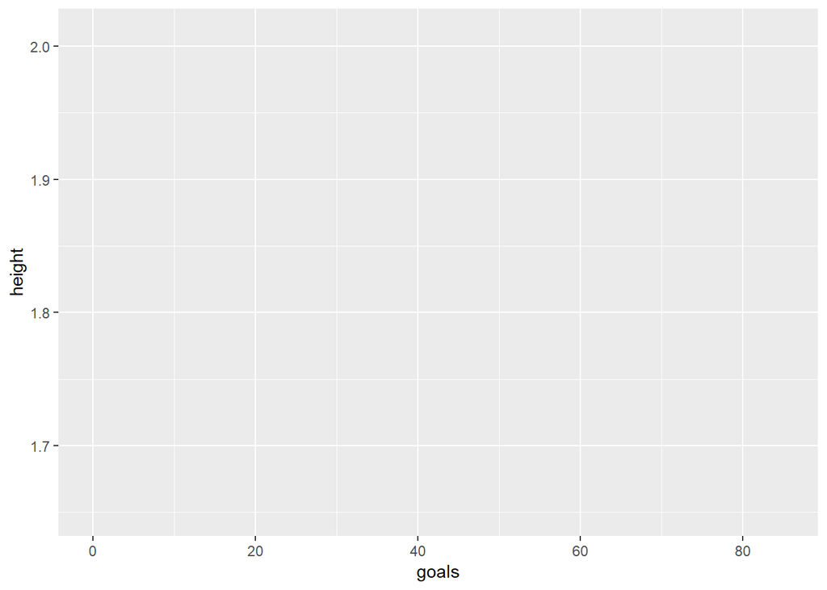

```r
library(ggplot2)
ggplot(fifa2018_1, aes(goals, height))
```

Um plot vazio é renderizado. Nós especificamos o que são x e y, não temos pontos, nem retas. Para o ggplot, se você não especificar qual é o formato do gráfico (pontos, linhas, barras etc.), ele não saberá o que você quer renderizar. Eu apenas falei qual banco usar, e quais variáveis são ser o x e y.

E a função aes() é usada para especificar os eixos x e y.

Para plotar pontos (por exemplo), preciso dizer que essa é a geometria que eu quero.

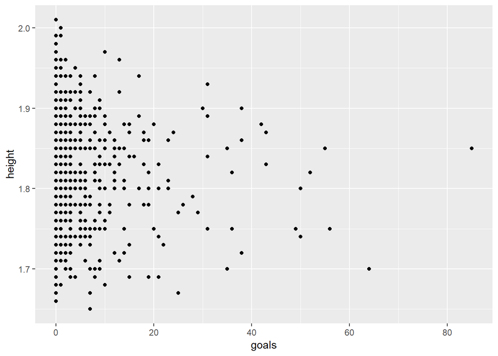

```r
#library(ggplot2)
ggplot(fifa2018_1, aes(goals, height)) + geom_point()
```

Agora temos um gráfico plotado. Cada ponto representa um jogador (altura e gools marcados). Muitas coisas podem ser customizadas nesse gráfico, como o nome das variáveis, nome do título de plot, cor de background, tamanho das fontes etc.

E temos muitas outras geometrias possíveis: geom_bar para gráfico de barra, geom_line para gráfico de linha e assim por diante.

De todo modo, vocês concordam que não há correlação entre altura e gols? Vamos traçar uma linha reta associado as duas variáveis, para visuzalizar melhor?

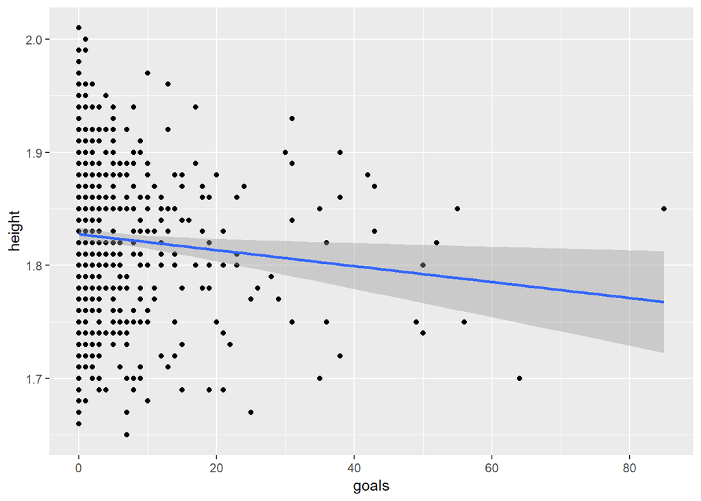

```r
#library(ggplot2)
ggplot(fifa2018_1, aes(goals, height)) + geom_point() +geom_smooth(method="lm")
```

Eu usei uma nova geometria, de alizamento (smooth), que plota um ajuste aos dados. No caso, um modelo liear (por isso method = “lm”, de linear model). Vejam quea correlação estimada é levemente negativa, mas ele também plotou um “intervalo de confiança”, e aí vemos que a correlação é próxima de zero. Se você quiser o plot sem os intervalos, basta colocar “se=FALSE” dentro de geom_smooth (separado por vírgula, pois é outro argumento) para remover os intervalos. De todo modo, será que se olharmos só para atacantes, a associação muda?

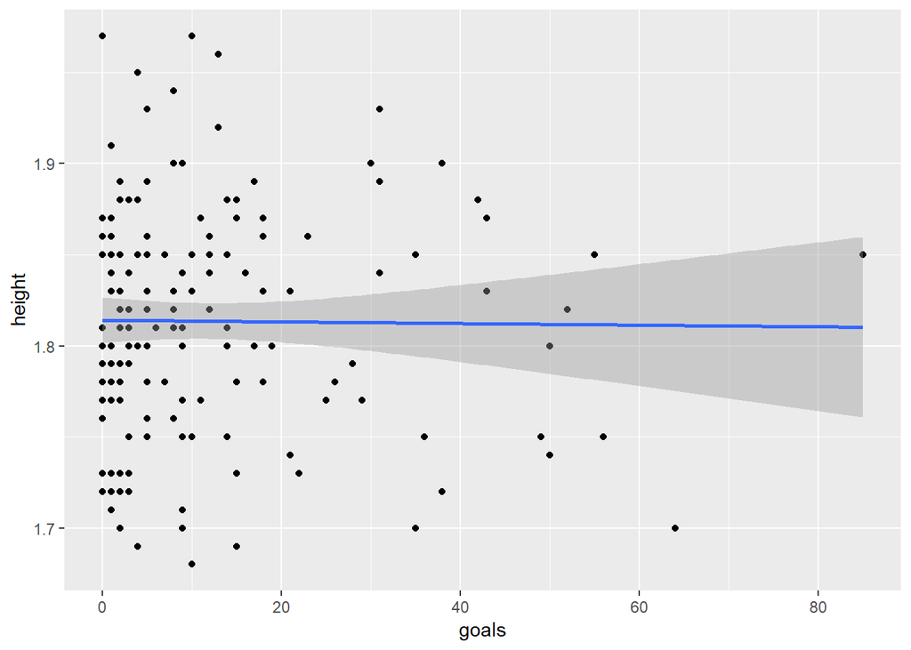

```r
#library(ggplot)
fifa2018_1  %>%
  filter(position == "FW") %>%
  ggplot(aes(goals, height)) + geom_point() + geom_smooth(method="lm")
```

Vejam que usei o filter para filtrar e, com o pipe, não precisei especificar qual o banco de dados. Ficou claro que só olhando para atacante, não tem correlaçção nenhuma.

Vamos só deixar o gráfico mais bonito? Vamos mudar os nomes das variáveiss e adicionar um título ao gráfico?

[figure not shown]

```r
#library(ggplot)
fifa2018_1  %>%
  filter(position == "FW") %>%
  ggplot(aes(goals, height)) + geom_point() + geom_smooth(method="lm") + xlab("Gols feitos") + ylab("Altura em cm") + ggtitle("Associação entre gols marcados por atacantes \n e altura dos jogadores das seleções de futebol", subtitle="Dados oficiais da Fifa")
```

xlab e ylab alteram o nome das variáveis x e y. E ggtitle altera o título do gráfico (e subtítulo). O

```r
"\n"
```

indica quebra de linha.

E seu eu quiser mudar outras coisa,s podemos usar um tema do ggplot. Por exemplo:

[figure not shown]

```r
#library(ggplot)
fifa2018_1  %>%
  filter(position == "FW") %>%
  ggplot(aes(goals, height)) + geom_point() + geom_smooth(method="lm") + theme_bw() + xlab("Gols feitos") + ylab("Altura em cm") + ggtitle("Associação entre gols marcados por atacantes \n e altura dos jogadores das seleções de futebol", subtitle="Dados oficiais da Fifa")
```

Com essa introdução a como operar com R, podemos agora mexer em dados mais úteis para análises de políticas públicas com R do que os dados da Fifa.